# about R Markdown

09 February 2018

## R rmarkdown

## R + Mark

- R: data, analyses, figures.
- What about Markdown?
  - [Wikipedia says](https://en.wikipedia.org/wiki/Markdown): “Markdown is a lightweight markup language with plain text formatting syntax.”
  - https://daringfireball.net/projects/markdown/

## Markdown

> Markdown is intended to be as easy-to-read and easy-to-write as is feasible.

`html`

```html
<a href="https://github.com/KevCaz/aboutRMarkdown">My repo</a>
```

`markdown`

```markdown
[My repo](https://github.com/KevCaz/aboutRMarkdown)
```

## Markdown

`html`

```html
<ol>
  <li> items1 </li>
  <li> items2 </li>
  <li> items3 </li>
</ol>
```

`markdown`

```markdown
1. items1
2. items2
3. items3
```

## Markdown *et al.*

- [GitHub Flavored Markdown (GFM)](https://help.github.com/articles/github-flavored-markdown/)
- [Kramdown](http://kramdown.gettalong.org/syntax.HTML#math-blocks)
- [Markdown Extra](https://michelf.ca/projects/php-markdown/extra/)
- [Multi Markdow](https://github.com/fletcher/MultiMarkdown/wiki/MultiMarkdown-Syntax-Guide#math-support)
- [Pandoc Markdown](http://pandoc.org/README.HTML#pandocs-markdown)

## Markdown suffered from bad parenting

https://blog.codinghorror.com/responsible-open-source-code-parenting/

> “I despise what you’ve done with Text::Markdown, which is to more or less make it an alias for MultiMarkdown, almost every part of which I disagree with in terms of syntax additions.” (John Gruber, on 15 Mar 2008)

## CommonMark

http://commonmark.org/

> “A strongly defined, highly compatible specification of Markdow.”

## Markdown everywhere

- Static Website generator ([jekyll](https://jekyllrb.com/), [hugo](https://gohugo.io/), …)
- R markdown
- [blogdown](https://bookdown.org/yihui/blogdown/) written using [bookdown](https://bookdown.org/yihui/bookdown/)
- [Slack](https://slack.com/)
- Github
- [Markdown here](https://markdown-here.com/)
- [Markdown here’s awesome markdown cheat sheet](https://github.com/adam-p/markdown-here/wiki/Markdown-Cheatsheet)

## Mail

[video not shown]

## R + markdown, how?

## One package to rule them all

https://rmarkdown.rstudio.com/

## R package `knitr`

https://yihui.name/knitr/

```{R name, options}

your_code

```

## `yaml`

- [Wikipedia says](https://en.wikipedia.org/wiki/YAML): “*YAML (YAML Ain’t Markup Language) is a human-readable data serialization language.*”

```yaml
author: Bill June
data: 2018-11-03
```

- metadata of your file

## `pandoc`

https://pandoc.org/

## So

1. writing `.Rmd` document
2. Click to obtain your final document (call `render()`)
3. `knitr` convert code chunk
4. you obtain a `.md` version
5. this `.md` file + yaml ==> pandoc

## Dynamic document

https://cran.r-project.org/web/packages/rmarkdown/

## Analysis

```r
cos(pi)
```

```
R>> [1] -1
```

```r
sin(3)
```

```
R>> [1] 0.14112
```

```r
exp(10)
```

```
R>> [1] 22026.47
```

## Figures

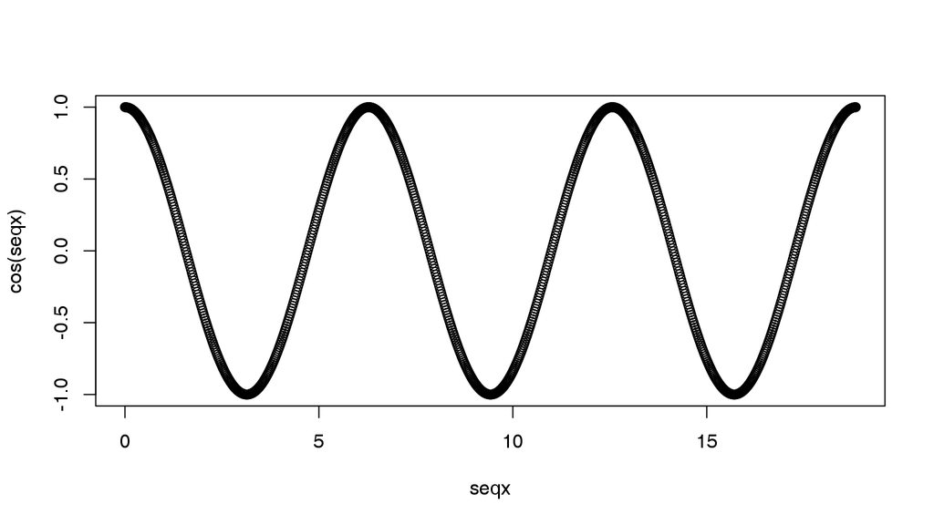

## Table

```r
head(CO2)
```

```
R>>   Plant   Type  Treatment conc uptake
R>> 1   Qn1 Quebec nonchilled   95   16.0
R>> 2   Qn1 Quebec nonchilled  175   30.4
R>> 3   Qn1 Quebec nonchilled  250   34.8
R>> 4   Qn1 Quebec nonchilled  350   37.2
R>> 5   Qn1 Quebec nonchilled  500   35.3
R>> 6   Qn1 Quebec nonchilled  675   39.2
```

## Table

```r
knitr::kable(head(CO2))
```

| Plant | Type | Treatment | conc | uptake |
| --- | --- | --- | --- | --- |
| Qn1 | Quebec | nonchilled | 95 | 16.0 |
| Qn1 | Quebec | nonchilled | 175 | 30.4 |
| Qn1 | Quebec | nonchilled | 250 | 34.8 |
| Qn1 | Quebec | nonchilled | 350 | 37.2 |
| Qn1 | Quebec | nonchilled | 500 | 35.3 |
| Qn1 | Quebec | nonchilled | 675 | 39.2 |

## Let’s practice

## Open a `Rmd` file in Rstudio

[video not shown]

## What does it look like?

[video not shown]

## Render your document

[video not shown]

Alternatively, you can use `render()`